# World Happiness Report

World happiness is an issue that affects each and every human living on Earth. In the following report my partner and I will look into the variables that correlate to a higher happiness score in specific countries. The World Happiness Report is released every year and gives an overview of countries ranked by happiness. The World Happinesss Report scores based on many variables including economy, family, health, freedom, trust, and generosity. In our initial data exploration we found the most significant variables to be economy and freedom. In this report we will test these variables and show why they correlate to a higher happiness score.

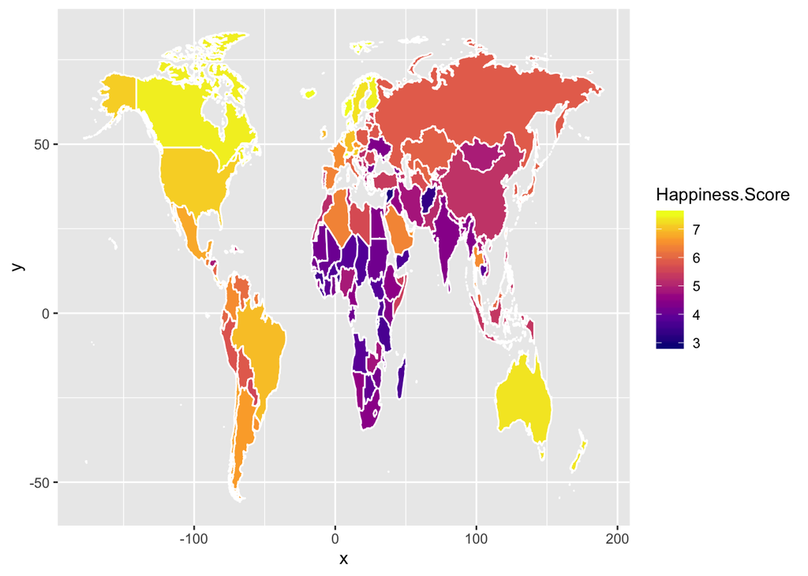

By the looks of it, North America, Austrailia, and Europe seem to be the overall happiest. Although Africa is missing a few countries, we can tell that is looks to be overall the least happy continent in the world. This tells us about the happiness in each country or region in the world which can be helpful later in determining where the variables that correlate to higher happiness are present or lacking.

```
##
## Call:
## lm(formula = Happiness.Score ~ Economy..GDP.per.Capita. + Freedom,
##     data = happy16)
##
## Residuals:
##      Min       1Q   Median       3Q      Max
## -1.84681 -0.36758  0.01282  0.39064  1.33653
##
## Coefficients:
##                          Estimate Std. Error t value Pr(>|t|)
## (Intercept)                2.6650     0.1530  17.417  < 2e-16 ***
## Economy..GDP.per.Capita.   1.8632     0.1277  14.594  < 2e-16 ***
## Freedom                    2.5334     0.3620   6.998 7.49e-11 ***
## ---
## Signif. codes:  0 '***' 0.001 '**' 0.01 '*' 0.05 '.' 0.1 ' ' 1
##
## Residual standard error: 0.6132 on 154 degrees of freedom
## Multiple R-squared:  0.7152, Adjusted R-squared:  0.7115
## F-statistic: 193.3 on 2 and 154 DF,  p-value: < 2.2e-16
```

The p-value is statistically significant, so the null hypothesis is rejected. The null hypothesis for these values is that the variables Economy and Freedom has a value of zero and has no bearing on the variable Happiness Score. This p-value indicates that there is a good probability of the two variables being correlated. The R-squared value indicates that approximately 71.5% of the variation of the y variable is predicted by the curve, which is pretty good for a multivariate regression.

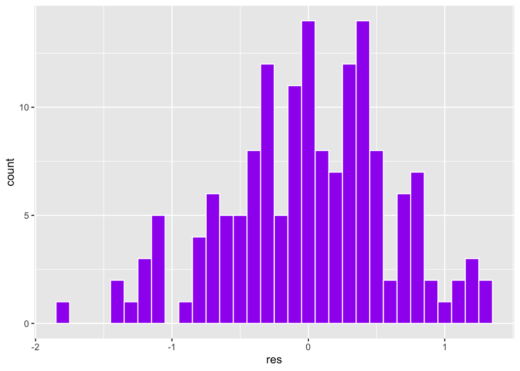

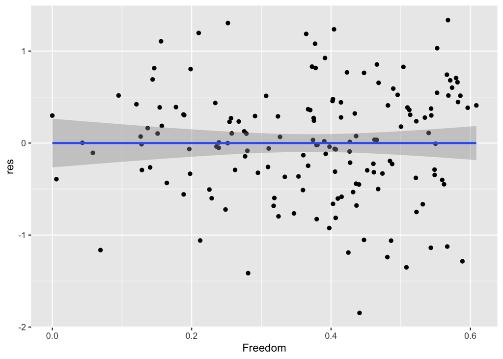

The histogram of residuals shows us that the residuals are normally distrubuted, something we need to be true to validate the model. The residual plot looks homoscedastic which is another thing we need to be true to validate the model. The final assumption we need to validate our model is that the data must be independent. We can assume this because we are measuring different countries freedom and economies which are independent.

Our data tells us that there is a correlation between the happiness score of a country and how free that country is doing or how well the economy is within its borders. We are limited in data points by this model. With only 157 countries, there is a very small sample size for determining which variables are significant. We can’t really do too much to change this in the future though because we are talking about the number of countries in the world which will stay constant. In the future, looking at other variables that impact happiness like geographical and population density could lead us to find more significant statistics that lead to happiness. We could possibly look at happiness among different categories like nationalities and ethnic groups which could lead us to further conclusions. We could also filter down by region and test countries within specific regions.